# Part I - Communicate Ford GoBike System Data Findings

## Introduction

The Ford GoBike System dateset contains information about individual rides made in a bike-sharing system covering the greater San Francisco Bay area.

Specific information being provided in the dataset include bike ID, user type, member gender, member birth year, start station ID and coordinates, end station ID and coordinates, trip start time, trip end time and trip duration.

## Preliminary Wrangling

```python
# import all packages and set plots to be embedded inline
import numpy as np
import pandas as pd
import matplotlib.pyplot as plt
import seaborn as sb

%matplotlib inline
```

```python
# load in the dataset into a pandas dataframe
df = pd.read_csv('201902-fordgobike-tripdata.csv')

# view the top five rows in the dataset
df.head()
```

|  | duration_sec | start_time | end_time | start_station_id | start_station_name | start_station_latitude | start_station_longitude | end_station_id | end_station_name | end_station_latitude | end_station_longitude | bike_id | user_type | member_birth_year | member_gender | bike_share_for_all_trip |
| --- | --- | --- | --- | --- | --- | --- | --- | --- | --- | --- | --- | --- | --- | --- | --- | --- |
| 0 | 52185 | 2019-02-28 17:32:10.1450 | 2019-03-01 08:01:55.9750 | 21.0 | Montgomery St BART Station (Market St at 2nd St) | 37.789625 | -122.400811 | 13.0 | Commercial St at Montgomery St | 37.794231 | -122.402923 | 4902 | Customer | 1984.0 | Male | No |
| 1 | 42521 | 2019-02-28 18:53:21.7890 | 2019-03-01 06:42:03.0560 | 23.0 | The Embarcadero at Steuart St | 37.791464 | -122.391034 | 81.0 | Berry St at 4th St | 37.775880 | -122.393170 | 2535 | Customer | NaN | NaN | No |
| 2 | 61854 | 2019-02-28 12:13:13.2180 | 2019-03-01 05:24:08.1460 | 86.0 | Market St at Dolores St | 37.769305 | -122.426826 | 3.0 | Powell St BART Station (Market St at 4th St) | 37.786375 | -122.404904 | 5905 | Customer | 1972.0 | Male | No |
| 3 | 36490 | 2019-02-28 17:54:26.0100 | 2019-03-01 04:02:36.8420 | 375.0 | Grove St at Masonic Ave | 37.774836 | -122.446546 | 70.0 | Central Ave at Fell St | 37.773311 | -122.444293 | 6638 | Subscriber | 1989.0 | Other | No |
| 4 | 1585 | 2019-02-28 23:54:18.5490 | 2019-03-01 00:20:44.0740 | 7.0 | Frank H Ogawa Plaza | 37.804562 | -122.271738 | 222.0 | 10th Ave at E 15th St | 37.792714 | -122.248780 | 4898 | Subscriber | 1974.0 | Male | Yes |

```python
# view the bottom five rows in the dataset
df.tail()
```

|  | duration_sec | start_time | end_time | start_station_id | start_station_name | start_station_latitude | start_station_longitude | end_station_id | end_station_name | end_station_latitude | end_station_longitude | bike_id | user_type | member_birth_year | member_gender | bike_share_for_all_trip |
| --- | --- | --- | --- | --- | --- | --- | --- | --- | --- | --- | --- | --- | --- | --- | --- | --- |
| 183407 | 480 | 2019-02-01 00:04:49.7240 | 2019-02-01 00:12:50.0340 | 27.0 | Beale St at Harrison St | 37.788059 | -122.391865 | 324.0 | Union Square (Powell St at Post St) | 37.788300 | -122.408531 | 4832 | Subscriber | 1996.0 | Male | No |
| 183408 | 313 | 2019-02-01 00:05:34.7440 | 2019-02-01 00:10:48.5020 | 21.0 | Montgomery St BART Station (Market St at 2nd St) | 37.789625 | -122.400811 | 66.0 | 3rd St at Townsend St | 37.778742 | -122.392741 | 4960 | Subscriber | 1984.0 | Male | No |
| 183409 | 141 | 2019-02-01 00:06:05.5490 | 2019-02-01 00:08:27.2200 | 278.0 | The Alameda at Bush St | 37.331932 | -121.904888 | 277.0 | Morrison Ave at Julian St | 37.333658 | -121.908586 | 3824 | Subscriber | 1990.0 | Male | Yes |
| 183410 | 139 | 2019-02-01 00:05:34.3600 | 2019-02-01 00:07:54.2870 | 220.0 | San Pablo Ave at MLK Jr Way | 37.811351 | -122.273422 | 216.0 | San Pablo Ave at 27th St | 37.817827 | -122.275698 | 5095 | Subscriber | 1988.0 | Male | No |
| 183411 | 271 | 2019-02-01 00:00:20.6360 | 2019-02-01 00:04:52.0580 | 24.0 | Spear St at Folsom St | 37.789677 | -122.390428 | 37.0 | 2nd St at Folsom St | 37.785000 | -122.395936 | 1057 | Subscriber | 1989.0 | Male | No |

```python
# view five random rows in the dataset
df.sample(5)
```

|  | duration_sec | start_time | end_time | start_station_id | start_station_name | start_station_latitude | start_station_longitude | end_station_id | end_station_name | end_station_latitude | end_station_longitude | bike_id | user_type | member_birth_year | member_gender | bike_share_for_all_trip |
| --- | --- | --- | --- | --- | --- | --- | --- | --- | --- | --- | --- | --- | --- | --- | --- | --- |
| 54622 | 344 | 2019-02-21 12:25:22.6060 | 2019-02-21 12:31:07.5360 | 99.0 | Folsom St at 15th St | 37.767037 | -122.415442 | 120.0 | Mission Dolores Park | 37.761420 | -122.426435 | 5097 | Subscriber | 1993.0 | Male | No |
| 130040 | 417 | 2019-02-09 20:23:20.9410 | 2019-02-09 20:30:18.7280 | 106.0 | Sanchez St at 17th St | 37.763242 | -122.430675 | 133.0 | Valencia St at 22nd St | 37.755213 | -122.420975 | 4780 | Customer | 1986.0 | Male | No |
| 120125 | 962 | 2019-02-11 17:09:43.4870 | 2019-02-11 17:25:45.7790 | 14.0 | Clay St at Battery St | 37.795001 | -122.399970 | 356.0 | Valencia St at Clinton Park | 37.769188 | -122.422285 | 5426 | Subscriber | 1990.0 | Male | No |
| 14544 | 1604 | 2019-02-27 11:42:14.0520 | 2019-02-27 12:08:58.5790 | 80.0 | Townsend St at 5th St | 37.775235 | -122.397437 | 3.0 | Powell St BART Station (Market St at 4th St) | 37.786375 | -122.404904 | 6562 | Subscriber | 1987.0 | Male | No |
| 75069 | 888 | 2019-02-19 09:18:10.5940 | 2019-02-19 09:32:59.3470 | 204.0 | 55th St at Telegraph Ave | 37.840186 | -122.261822 | 269.0 | Telegraph Ave at Carleton St | 37.862320 | -122.258801 | 1363 | Customer | 1995.0 | Male | No |

```python
# view all variables and their data types in the dataset
df.info()
```

```
<class 'pandas.core.frame.DataFrame'>
RangeIndex: 183412 entries, 0 to 183411
Data columns (total 16 columns):
 #   Column                   Non-Null Count   Dtype
---  ------                   --------------   -----
 0   duration_sec             183412 non-null  int64
 1   start_time               183412 non-null  object
 2   end_time                 183412 non-null  object
 3   start_station_id         183215 non-null  float64
 4   start_station_name       183215 non-null  object
 5   start_station_latitude   183412 non-null  float64
 6   start_station_longitude  183412 non-null  float64
 7   end_station_id           183215 non-null  float64
 8   end_station_name         183215 non-null  object
 9   end_station_latitude     183412 non-null  float64
 10  end_station_longitude    183412 non-null  float64
 11  bike_id                  183412 non-null  int64
 12  user_type                183412 non-null  object
 13  member_birth_year        175147 non-null  float64
 14  member_gender            175147 non-null  object
 15  bike_share_for_all_trip  183412 non-null  object
dtypes: float64(7), int64(2), object(7)
memory usage: 22.4+ MB
```

```python
# check for duplicated rows in the dataset
df.duplicated().sum()
```

```
0
```

```python
df.isna().sum()
```

```
duration_sec                  0
start_time                    0
end_time                      0
start_station_id            197
start_station_name          197
start_station_latitude        0
start_station_longitude       0
end_station_id              197
end_station_name            197
end_station_latitude          0
end_station_longitude         0
bike_id                       0
user_type                     0
member_birth_year          8265
member_gender              8265
bike_share_for_all_trip       0
dtype: int64
```

```python
# view the number of unique variables in the dataset
df.nunique()
```

```
duration_sec                 4752
start_time                 183401
end_time                   183397
start_station_id              329
start_station_name            329
start_station_latitude        334
start_station_longitude       335
end_station_id                329
end_station_name              329
end_station_latitude          335
end_station_longitude         335
bike_id                      4646
user_type                       2
member_birth_year              75
member_gender                   3
bike_share_for_all_trip         2
dtype: int64
```

```python
# view count for each unique user type
df.user_type.value_counts()
```

```
Subscriber    163544
Customer       19868
Name: user_type, dtype: int64
```

```python
# view count for each unique member gender
df.member_gender.value_counts()
```

```
Male      130651
Female     40844
Other       3652
Name: member_gender, dtype: int64
```

```python
# view count for each unique bike share
df.bike_share_for_all_trip.value_counts()
```

```
No     166053
Yes     17359
Name: bike_share_for_all_trip, dtype: int64
```

### What is the structure of your dataset?

The dataset contains records for 183412 bike rides that happened February, 2019 in San Francisco Bay area.

### What is/are the main feature(s) of interest in your dataset?

My main features of interest are in how user characteristics such as age, gender and purpose in the Ford GoBike sytem data, influence bike usage in the forms of trip duration, start time, start day, distance and bike sharing. It is my assumption that trip duration varies directly as the distance between start and end stations.

### What features in the dataset do you think will help support your investigation into your feature(s) of interest?

- duration_sec
- start_time
- start_station_name
- start_station_latitude
- start_station_longitude
- end_station_name
- end_station_latitude
- end_station_longitude
- member_birth_year
- member_gender

## Dataset Quality Issues

- Presence of rows with missing values.
- Some columns are not needed.
- Dataset contains ages which are considered not ideal for bike users.
- The start_station_id, end_station_id and bike_id variables should be of string data types.
- The start_time and end_time variables should be of datetime data types.
- The user_type and member_gender variables should be of category data types.

# Data Cleaning

Making a duplicate of the DataFrame before cleaning.

```python
# make a copy of the original dataset
df_clean = df.copy()
```

### Define

- Drop all rows with missing values.

### Code

```python
# drop all rows with missing values
df_clean.dropna(axis = 0, inplace = True)
```

### Test

```python
# check for rows with missing values
df_clean.isna().sum()
```

```
duration_sec               0
start_time                 0
end_time                   0
start_station_id           0
start_station_name         0
start_station_latitude     0
start_station_longitude    0
end_station_id             0
end_station_name           0
end_station_latitude       0
end_station_longitude      0
bike_id                    0
user_type                  0
member_birth_year          0
member_gender              0
bike_share_for_all_trip    0
dtype: int64
```

### Define

- Change the start_station_id, end_station_id and bike_id variables to string data types.

### Code

```python
def to_str(df, variables):
    """
    This function converts a given variable to a string data type.

    Parameters:
        df: DataFrame of interest
        variable (String): Variable to be converted
    """
    for variable in variables:
        df[variable] = df[variable].astype(str)
    return df
```

```python
# convert specified variables to string data types
df_clean = to_str(df_clean, ['start_station_id', 'end_station_id','bike_id'])
```

### Test

```python
# check for conversion success
df_clean[['start_station_id', 'end_station_id','bike_id']].info()
```

```
<class 'pandas.core.frame.DataFrame'>
Int64Index: 174952 entries, 0 to 183411
Data columns (total 3 columns):
 #   Column            Non-Null Count   Dtype
---  ------            --------------   -----
 0   start_station_id  174952 non-null  object
 1   end_station_id    174952 non-null  object
 2   bike_id           174952 non-null  object
dtypes: object(3)
memory usage: 5.3+ MB
```

### Define

- Change the start_time and end_time variables to datetime data types.

### Code

```python
def to_timestamp(df, variables):
    """
    This function converts a given variable to a datetime data type.

    Parameters:
        df: DataFrame of interest
        variable (String): Variable to be converted
    """
    for variable in variables:
        df[variable] = pd.to_datetime(df[variable])
    return df
```

```python
# convert specified variables to datetime data types
df_clean = to_timestamp(df_clean, ['start_time', 'end_time'])
```

### Test

```python
# check for conversion success
df_clean[['start_time', 'end_time']].info()
```

```
<class 'pandas.core.frame.DataFrame'>
Int64Index: 174952 entries, 0 to 183411
Data columns (total 2 columns):
 #   Column      Non-Null Count   Dtype
---  ------      --------------   -----
 0   start_time  174952 non-null  datetime64[ns]
 1   end_time    174952 non-null  datetime64[ns]
dtypes: datetime64[ns](2)
memory usage: 4.0 MB
```

### Define

- Change the user_type and member_gender variables to category data types.

### Code

```python
def to_category(df, variables):
    """
    This function converts a given variable to a category data type.

    Parameters:
        df: DataFrame of interest
        variable (String): Variable to be converted
    """
    for variable in variables:
        df[variable] = df[variable].astype('category')
    return df
```

```python
# convert specified variables to category data types
df_clean = to_category (df_clean, ['user_type', 'member_gender'])
```

### Test

```python
#check for conversion success
df_clean[['user_type', 'member_gender']].info()
```

```
<class 'pandas.core.frame.DataFrame'>
Int64Index: 174952 entries, 0 to 183411
Data columns (total 2 columns):
 #   Column         Non-Null Count   Dtype
---  ------         --------------   -----
 0   user_type      174952 non-null  category
 1   member_gender  174952 non-null  category
dtypes: category(2)
memory usage: 1.7 MB
```

### Code

Create columns for depicting start days and months.

```python
# create new columns for indicating the start hour, day and month
df_clean['start_day'] = df_clean['start_time'].dt.day_name()
df_clean['start_month'] = df_clean['start_time'].dt.month_name()
df_clean['start_hour']= df_clean['start_time'].dt.hour
```

```python
# check for successful creation of the start day column
df_clean['start_day'].value_counts()
```

```
Thursday     33712
Tuesday      30584
Wednesday    28426
Friday       27663
Monday       25641
Sunday       14512
Saturday     14414
Name: start_day, dtype: int64
```

```python
# check for successful creation of the start month column
df_clean['start_month'].value_counts()
```

```
February    174952
Name: start_month, dtype: int64
```

Dataset contains entries for the month of February, 2019 only.

```python
# check for successful creation of the start hour column
df_clean['start_hour'].value_counts()
```

```
17    20904
8     20227
18    16118
9     15204
16    13473
7     10231
19     9424
15     8646
12     8220
13     8098
10     7970
14     7677
11     7461
20     6211
21     4400
6      3293
22     2793
23     1572
0       893
5       866
1       525
2       355
4       227
3       164
Name: start_hour, dtype: int64
```

Create a new column to depict age

```python
# subtract birth year from 2019 to obtain user age
df_clean['age'] = (2019 - df_clean['member_birth_year']).round(0)
```

Create a new column converting duration from seconds to minutes

```python
# convert time from seconds to minutes to enhance compactness
df_clean['duration_min'] = (df_clean['duration_sec'] / 60).round(2)
```

Create a new column representing the distance between start and end stations.

```python
# code copied form "Getting distance between two points based on latitude/longitude" on stackoverflow
# https://stackoverflow.com/questions/19412462/getting-distance-between-two-points-based-on-latitude-longitude
from math import sin, cos, sqrt, atan2, radians

def distance (lat1, lon1, lat2, lon2):
    # multiply R, earth's radius (km), by 0.621 to convert it to miles
    R = 6373.0 * 0.621

    lat1 = radians(lat1)
    lon1 = radians(lon1)
    lat2 = radians(lat2)
    lon2 = radians(lon2)

    dlon = lon2 - lon1
    dlat = lat2 - lat1

    a = sin(dlat / 2)**2 + cos(lat1) * cos(lat2) * sin(dlon / 2)**2
    c = 2 * atan2(sqrt(a), sqrt(1 - a))

    d = R * c
    return d
```

```python
# create a column for the distance covered
df_clean['distance_miles'] = (df_clean.apply(lambda x: distance(x['start_station_latitude'], x['start_station_longitude'],
                                             x['end_station_latitude'], x['end_station_longitude']),axis=1)).round(3)
```

### Test

```python
# check for inclusion of all the newly created columns
df_clean.info()
```

```
<class 'pandas.core.frame.DataFrame'>
Int64Index: 174952 entries, 0 to 183411
Data columns (total 22 columns):
 #   Column                   Non-Null Count   Dtype
---  ------                   --------------   -----
 0   duration_sec             174952 non-null  int64
 1   start_time               174952 non-null  datetime64[ns]
 2   end_time                 174952 non-null  datetime64[ns]
 3   start_station_id         174952 non-null  object
 4   start_station_name       174952 non-null  object
 5   start_station_latitude   174952 non-null  float64
 6   start_station_longitude  174952 non-null  float64
 7   end_station_id           174952 non-null  object
 8   end_station_name         174952 non-null  object
 9   end_station_latitude     174952 non-null  float64
 10  end_station_longitude    174952 non-null  float64
 11  bike_id                  174952 non-null  object
 12  user_type                174952 non-null  category
 13  member_birth_year        174952 non-null  float64
 14  member_gender            174952 non-null  category
 15  bike_share_for_all_trip  174952 non-null  object
 16  start_day                174952 non-null  object
 17  start_month              174952 non-null  object
 18  start_hour               174952 non-null  int64
 19  age                      174952 non-null  float64
 20  duration_min             174952 non-null  float64
 21  distance_miles           174952 non-null  float64
dtypes: category(2), datetime64[ns](2), float64(8), int64(2), object(8)
memory usage: 28.4+ MB
```

### Test

```python
# check if the drop action action was successful
df_clean.info()
```

```
<class 'pandas.core.frame.DataFrame'>
Int64Index: 174952 entries, 0 to 183411
Data columns (total 22 columns):
 #   Column                   Non-Null Count   Dtype
---  ------                   --------------   -----
 0   duration_sec             174952 non-null  int64
 1   start_time               174952 non-null  datetime64[ns]
 2   end_time                 174952 non-null  datetime64[ns]
 3   start_station_id         174952 non-null  object
 4   start_station_name       174952 non-null  object
 5   start_station_latitude   174952 non-null  float64
 6   start_station_longitude  174952 non-null  float64
 7   end_station_id           174952 non-null  object
 8   end_station_name         174952 non-null  object
 9   end_station_latitude     174952 non-null  float64
 10  end_station_longitude    174952 non-null  float64
 11  bike_id                  174952 non-null  object
 12  user_type                174952 non-null  category
 13  member_birth_year        174952 non-null  float64
 14  member_gender            174952 non-null  category
 15  bike_share_for_all_trip  174952 non-null  object
 16  start_day                174952 non-null  object
 17  start_month              174952 non-null  object
 18  start_hour               174952 non-null  int64
 19  age                      174952 non-null  float64
 20  duration_min             174952 non-null  float64
 21  distance_miles           174952 non-null  float64
dtypes: category(2), datetime64[ns](2), float64(8), int64(2), object(8)
memory usage: 28.4+ MB
```

```python
# description of the numerical variables left
df_clean[['start_hour', 'age', 'duration_min', 'distance_miles']].describe()
```

|  | start_hour | age | duration_min | distance_miles |
| --- | --- | --- | --- | --- |
| count | 174952.000000 | 174952.000000 | 174952.000000 | 174952.000000 |
| mean | 13.456165 | 34.196865 | 11.733373 | 1.049848 |
| std | 4.734282 | 10.118731 | 27.370085 | 0.681428 |
| min | 0.000000 | 18.000000 | 1.020000 | 0.000000 |
| 25% | 9.000000 | 27.000000 | 5.380000 | 0.566000 |
| 50% | 14.000000 | 32.000000 | 8.500000 | 0.888000 |
| 75% | 17.000000 | 39.000000 | 13.150000 | 1.382000 |
| max | 23.000000 | 141.000000 | 1409.130000 | 43.154000 |

### Define

- Drop ages which are considered not ideal for bike users.

### Code

```python
# Using 80 years as the maximum age
df_clean = df_clean[df_clean.age < 81]
```

### Test

```python
# check if 80 years is the new maximum age
df_clean[['age']].max()
```

```
age    80.0
dtype: float64
```

## Univariate Exploration

### Question 1: What is the general preference for user type?

```python
# obtain count for each user type
type_count = (df_clean['user_type']).value_counts()
type_count
```

```
Subscriber    158203
Customer       16557
Name: user_type, dtype: int64
```

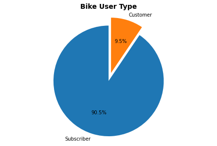

```python
# make a pie chart plot of the user type
plt.pie(type_count, labels = ['Subscriber', 'Customer'], startangle = 90, explode=(0, .15), autopct = '%1.1f%%');
plt.axis('equal')
plt.title('Bike User Type', size = 14, weight = 'bold')
plt.subplots_adjust(bottom = 0, top = 0.93, left = 0.0, right = 1.0);
```

Observation 1: The user type pie chart shows that majority of the bike users are subscribers.

### Question 2: Which gender makes the most use of bikes?

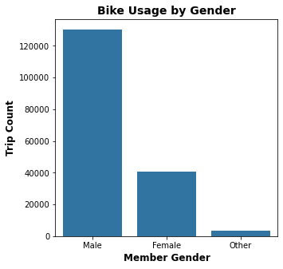

```python
# obtain count for each gender type
gender_count = df_clean['member_gender'].value_counts().reset_index(name = 'number_of_trips')
gender_order = gender_count['index']

# adjust figure size
plt.figure(figsize = [5, 5])
# set base color
base_color = sb.color_palette()[0]
# make a bar plot of the member gender
sb.countplot(data = df_clean, x = 'member_gender', color = base_color, order = gender_order)
# add x label and format it
plt.xlabel('Member Gender', size = 12, weight = 'bold')
# add y label and format it
plt.ylabel('Trip Count', size = 12, weight = 'bold')
# add title and format it
plt.title('Bike Usage by Gender', size = 14, weight = 'bold');
```

Observation 2: Males make more use of the bikes than any other gender.

### Question 3: Which start and end stations are the most commonly used?

```python
def bar_plot(df, var_name, x_label, title):
    """
    This function makes a bar plot of a specified variable.

    Parameters:
        df: DataFrame of interest
        var_name (string): Name of variable to be plotted
        x_label (string): horizontal axis label
        title (string): plot title.
    """
    # order the unique values by count
    var_count = df[var_name].value_counts()[:25]

    # make a bar plot of the variable
    sb.countplot(data = df, y = var_name, order = var_count.index, color = base_color)
    # add x label
    plt.xlabel(x_label, weight = 'bold')
    # override the default y label
    plt.ylabel(None)
    # add title and format it
    plt.title(title, size = 14, weight = 'bold')
```

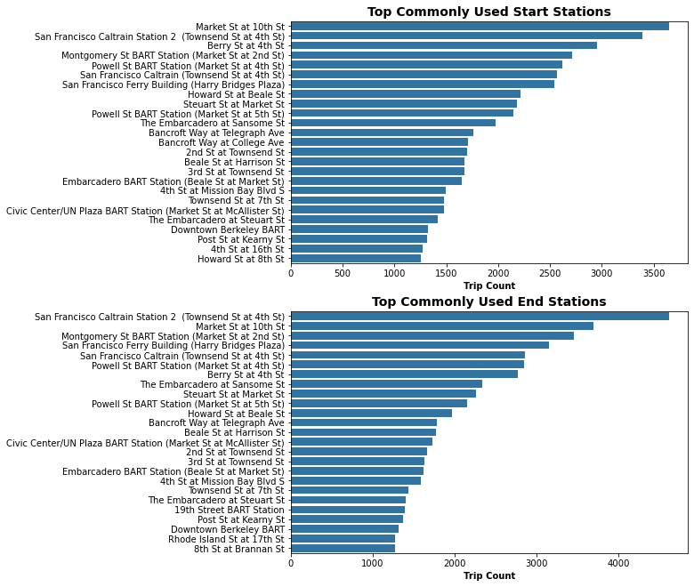

```python
# set base olor
base_color = sb.color_palette()[0]
# adjust figure size
plt.figure(figsize = [8, 11])

# make a subplot of start station names
plt.subplot(2,1,1)
bar_plot(df_clean, 'start_station_name', 'Trip Count', 'Top Commonly Used Start Stations')

# make a subplot of end station names
plt.subplot(2,1,2)
bar_plot(df_clean, 'end_station_name', 'Trip Count', 'Top Commonly Used End Stations');
```

Observation 3: Market St is the most commonly used start station, while San Francisco Caltrain Station 2 is the most commonly used end station.

```python
def bar_plot(df, var_count, var_name, x_label, y_label, title, order = None):
    """
    This function makes a bar plot of a specified variable.

    Parameters:
        df: DataFrame of interest
        var_count (String): Variable count
        order (String): Variable order
        var_name (string): Variable to be plotted
        x_label (string): horizontal axis label
        y_label (string): vertical axis label.
        title (string): plot title.
    """
    # order the unique values by count
    var_count = df[var_name].value_counts()

    # adjust figure size
    plt.figure(figsize = [11, 5])
    # set base color
    base_color = sb.color_palette()[0]
    # make a bar plot of the variable
    sb.countplot(data = df, x = var_name, color = base_color, order = order)
    # add x label and format it
    plt.xlabel(x_label, size = 12, weight = 'bold')
    # add y label and format it
    plt.ylabel(y_label, size = 12, weight = 'bold')
    # add title and format it
    plt.title(title, size = 14, weight = 'bold');
```

### Question 4: Which hour is the most active for bike usage?

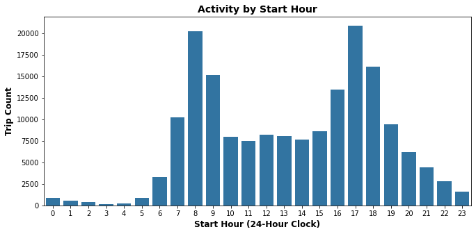

```python
# make a bar plot of the start hour variable
bar_plot(df_clean, 'hour_count', 'start_hour', 'Start Hour (24-Hour Clock)', 'Trip Count', 'Activity by Start Hour');
```

Observation 4: 8:00 AM and 5:00 PM are the peak hours of bike usage. These hours correspond to mornings and late noons.

### Question 5: Which day is the most active for bike usage?

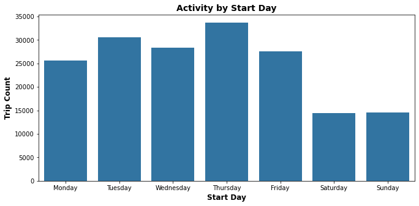

```python
# set horiontal axis label order
day_order = ['Monday', 'Tuesday', 'Wednesday', 'Thursday', 'Friday', 'Saturday', 'Sunday']
# make a bar plot of the start day variable
bar_plot(df_clean, 'day_count', 'start_day', 'Start Day', 'Trip Count', 'Activity by Start Day', order = day_order);
```

Observation 5: Thursdays are the most active start days, while Saturdays are the least.

### Question 6: What is the age distribution of the bike users?

```python
# obtain the age boundaries
df_clean[['age']].describe()
```

|  | age |
| --- | --- |
| count | 174760.000000 |
| mean | 34.125223 |
| std | 9.877739 |
| min | 18.000000 |
| 25% | 27.000000 |
| 50% | 32.000000 |
| 75% | 39.000000 |
| max | 80.000000 |

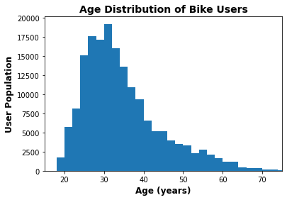

```python
# set the bin edges
bin_edges = np.arange(0, df_clean['age'].max() +2, 2)
# make a histogram plot of the age variable
plt.hist(data = df_clean, x = 'age', bins = bin_edges)
# add x label and format it
plt.xlabel('Age (years)', size = 12, weight = 'bold')
# add y label and format it
plt.ylabel('User Population', size = 12, weight = 'bold')
# add title and format it.
plt.title('Age Distribution of Bike Users', size = 14, weight = 'bold')
# set horizontal axis limit
plt.xlim([15, 75]);
```

Observation 6: Most bike users are between the ages of 26 and 36 years.

### Question 7: What is the distribution of the trip duration?

```python
# obtain the duration boundaries
df_clean[['duration_min']].describe()
```

|  | duration_min |
| --- | --- |
| count | 174760.000000 |
| mean | 11.738488 |
| std | 27.383864 |
| min | 1.020000 |
| 25% | 5.380000 |
| 50% | 8.520000 |
| 75% | 13.150000 |
| max | 1409.130000 |

Observation: The minimum trip duration is 1 minute, 75% of the durations fall below 13 minutes, while the maximum duration is 1409. This implies that ideal scale for the plot would be a log scale.

```python
# check the log transformation of the boundaries
np.log10(df_clean['duration_min'].describe())
```

```
count    5.242442
mean     1.069612
std      1.437495
min      0.008600
25%      0.730782
50%      0.930440
75%      1.118926
max      3.148951
Name: duration_min, dtype: float64
```

Observation: Now this looks better.

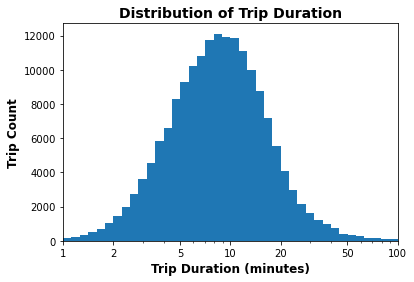

```python
# set the bin edges
bin_edges = 10 ** np.arange(0, 3.15 +0.05, 0.05)
# set the horizontal axis marks
ticks = [1, 2, 5, 10, 20, 50, 100, 200, 500, 1000]
plt.hist(data = df_clean, x = 'duration_min', bins = bin_edges)
# transform the horizontal axis into a log scale
plt.xscale("log")
# format the horizontal axis label to override the default standard forms for log scales
labels = ['{}'.format(v) for v in ticks]
plt.xticks(ticks, labels)
# add x label and format it
plt.xlabel('Trip Duration (minutes)', size = 12, weight = 'bold')
# add y label and format it
plt.ylabel('Trip Count', size = 12, weight = 'bold')
# add title and format it
plt.title('Distribution of Trip Duration', size = 14, weight = 'bold')
# set horizontal axis limit
plt.xlim([1, 100]);
```

Observation 7: Most trip durations fall between 4 and 20 minutes.

### Question 8: What is the distribution of the trip distance?

```python
# check description of the distance covered
df_clean[['distance_miles']].describe()
```

|  | distance_miles |
| --- | --- |
| count | 174760.000000 |
| mean | 1.050106 |
| std | 0.681249 |
| min | 0.000000 |
| 25% | 0.566000 |
| 50% | 0.888000 |
| 75% | 1.382000 |
| max | 43.154000 |

Observation: The minimum distance is 0.000 miles, the maximum distance is 43.154 miles, and 75% of the estimated distances fall below 1.382 miles. It seems ideal to use a range plot.

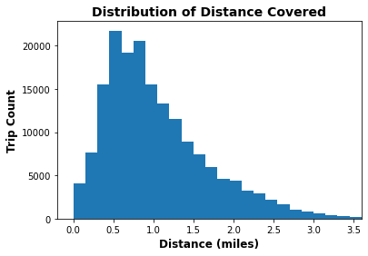

```python
# set the bin edges
bin_edges = np.arange(0, df_clean['distance_miles'].max() + 0.15, 0.15)
# make a histogram plot of the variable
plt.hist(data = df_clean, x ='distance_miles', bins = bin_edges)
# add x label and format it
plt.xlabel('Distance (miles)', size = 12, weight = 'bold')
# add y label and format it
plt.ylabel('Trip Count', size = 12, weight = 'bold')
# add title and format it
plt.title('Distribution of Distance Covered', size = 14, weight = 'bold')
plt.xlim([-0.2, 3.6]);
```

Observation 8: Most of the trip distances fall within the range of 0.5 and 1.5 miles.

### Discuss the distribution(s) of your variable(s) of interest. Were there any unusual points? Did you need to perform any transformations?

- The trip distance data seemed to have an outlier. A range plot was needed to obtain a meaningful plot.
- A logarithmic transformation was performed on the trip duration entries, in order to normalise the distribution.

### Of the features you investigated, were there any unusual distributions? Did you perform any operations on the data to tidy, adjust, or change the form of the data? If so, why did you do this?

- The distributions for age and trip distance were right skewed, while the one for trip duration was normal.
- Trip distance was feature-engineered from both longitude and latitude coordinates, in order to investigate its correlation with duration of trip.

## Bivariate Exploration

### Question 9: Is there a relationship between trip duration and trip distance?

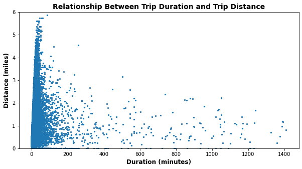

```python
# make a scatter plot between the variables
df_clean.plot(x = 'duration_min', y = 'distance_miles', kind = 'scatter', figsize = (10, 5), s = 5)
# add x label and format it
plt.xlabel('Duration (minutes)', fontsize = 12, weight = 'bold')
# add y label and format it
plt.ylabel('Distance (miles)', fontsize = 12, weight = 'bold')
# add plot title and format it
plt.title('Relationship Between Trip Duration and Trip Distance', size = 14, weight = 'bold')
# set vertical axis limit
plt.ylim([0, 6]);
```

```python
# check the correlation coefficient between the variables
print(df_clean['duration_min'].corr(df_clean['distance_miles']))
```

```
0.14104091145447267
```

Observation 9: Surprisingly, there is a very weak correlation between trip duration and trip distance.

### Question 10: Does user type have any effect on bike sharing?

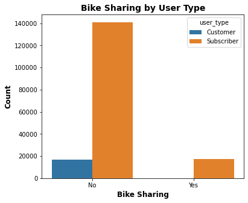

```python
# set figure size
plt.figure(figsize = [6, 5])
# make a bar plot of the variables
sb.countplot(data = df_clean, x = 'bike_share_for_all_trip', hue = 'user_type')
# add x label and format it
plt.xlabel('Bike Sharing', size = 12, weight = 'bold')
# add y label and format it
plt.ylabel('Count', size = 12, weight = 'bold')
# add title and format it
plt.title('Bike Sharing by User Type', size = 14, weight = 'bold');
```

Observation 10: Bike sharing is only observed among subscribers. Customers do not share bikes.

```python
def bi_plot(plot_type, df, x_data, y_data, order = None):
    """
    This function makes a either a violin or box plot between to specified variables.

    Parameters:
        df: DataFrame of interest
        plot_type: Plot type, either violin plot (sb.violinplot) or box plot (sb.boxplot)
        x_data (string): Variable on the x_axis.
        y_data (string): Variable on the y_axis.

    """
    plot_type(data = df, x = x_data, y = y_data, color = sb.color_palette()[0], order = order)
    # tidy up labels after plotting
    x_data = x_data.replace('_', ' ') # replace underscore symbol with space
    y_data = y_data.replace('_', ' ') # replace underscore symbol with space
    # add x label and format it
    plt.xlabel(x_data.title(), size = 12, weight = 'bold')
    # add y label and format it
    plt.ylabel(y_data.title(), size = 12, weight = 'bold')
    # add title and format it
    plt.title(f'Distribution of {y_data} by {x_data}'.title(), size = 14, weight = 'bold')
```

### Question 11: Is there any connection between trip start hour and day of the week?

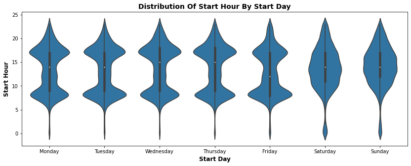

```python
# set figure size
plt.figure(figsize = [14, 5])
# make the desired plot
bi_plot(sb.violinplot, df_clean, 'start_day', 'start_hour', order = day_order);
```

Observation 11: On weekdays, the peak hours for trips are 8:00 AM and 5:00 PM. But on weekends, the peak start hour is by 12:00 noon.

### Question 12: What is the relationship between user type and age?

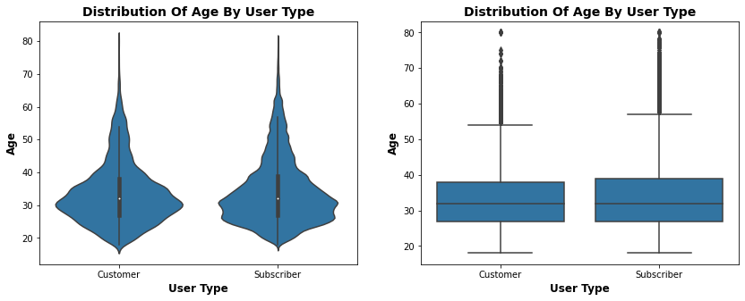

```python
# set figuresize
plt.figure(figsize = [14, 5])

# make the desired plots
plt.subplot(1, 2, 1)
bi_plot(sb.violinplot, df_clean, 'user_type', 'age')

plt.subplot(1, 2, 2)
bi_plot(sb.boxplot, df_clean, 'user_type', 'age');
```

Observation 12: Most bike users fall within the ages of 25 and 35 years.

### Question 13: Does age affect bike sharing?

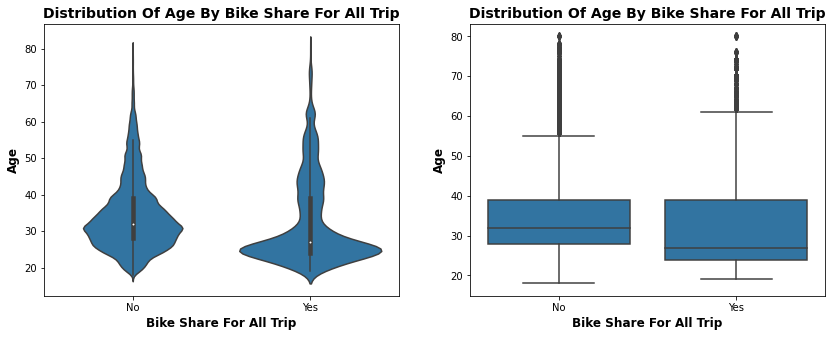

```python
# set figure size
plt.figure(figsize = [14, 5])

# make the desired plots
plt.subplot(1, 2, 1)
bi_plot(sb.violinplot, df_clean, 'bike_share_for_all_trip', 'age')

plt.subplot(1, 2, 2)
bi_plot(sb.boxplot, df_clean, 'bike_share_for_all_trip', 'age');
```

Observation 13: Users who are about 32 years of age have the least likelihood to share bikes, while those who are about 25 years of age have the highest tendencies to share bikes.

### Question 14: How does user type affect trip distance?

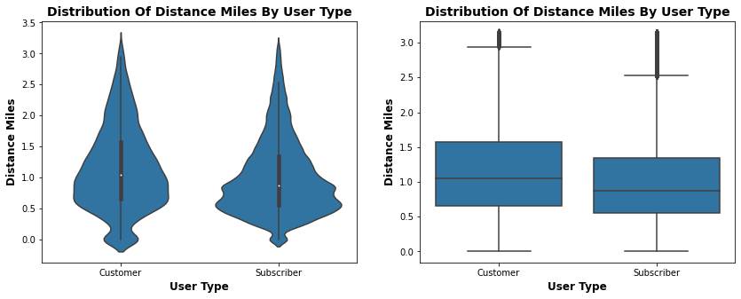

```python
# set figure size
plt.figure(figsize = [14, 5])

# make the desired plots
plt.subplot(1, 2, 1)
bi_plot(sb.violinplot, df_clean.query('distance_miles < distance_miles.quantile(0.99)'), 'user_type', 'distance_miles')

plt.subplot(1, 2, 2)
bi_plot(sb.boxplot, df_clean.query('distance_miles < distance_miles.quantile(0.99)'), 'user_type', 'distance_miles');
```

Observation 14: A larger population of customers tend to travel farther distances compared to subscribers.

### Question 15: What is the relationship between member gender and age?

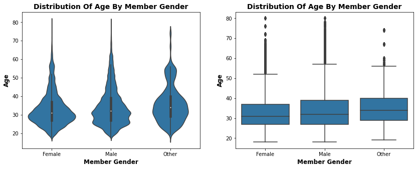

```python
# set figure size
plt.figure(figsize = [14, 5])

# make the desired plots
plt.subplot(1, 2, 1)
bi_plot(sb.violinplot, df_clean, 'member_gender', 'age')

plt.subplot(1, 2, 2)
bi_plot(sb.boxplot, df_clean, 'member_gender', 'age');
```

Observation 15: Across all gender types, people who are about 32 years of age have the highest likelihood to use bikes. Furthermore, users who are of other gender types still have high tendencies to be bike users even at 40 years of age.

### Question 16: How does user type affect trip duration?

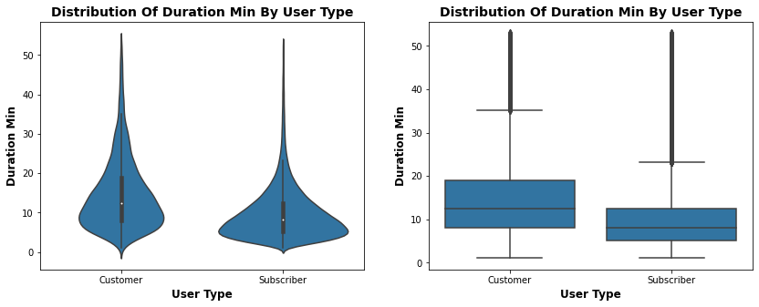

```python
# set figure size
plt.figure(figsize = [14, 5])

# make the desired plots
plt.subplot(1, 2, 1)
bi_plot(sb.violinplot, df_clean.query('duration_min < duration_min.quantile(0.99)'), 'user_type', 'duration_min')

plt.subplot(1, 2, 2)
bi_plot(sb.boxplot, df_clean.query('duration_min < duration_min.quantile(0.99)'), 'user_type', 'duration_min');
```

Observation 16: A larger population of customers spend longer durations on trips compared to subscribers.

### Question 17: Has trip start hour got any effect on bike sharing?

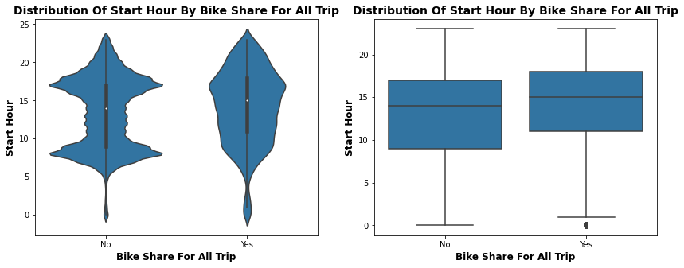

```python
# set figure size
plt.figure(figsize = [14, 5])

# make the desired plots
plt.subplot(1, 2, 1)
bi_plot(sb.violinplot, df_clean, 'bike_share_for_all_trip', 'start_hour')

plt.subplot(1, 2, 2)
bi_plot(sb.boxplot, df_clean, 'bike_share_for_all_trip', 'start_hour');
```

Observation 17: Users who start their trips by 8:00 AM will most likely not share bikes, while those who start by 5:00 PM will most likely share bikes.

### Talk about some of the relationships you observed in this part of the investigation. How did the feature(s) of interest vary with other features in the dataset?

- On weekdays, the peak hours for trips are 8:00 AM and 5:00 PM. But on weekends, the peak start hour is by 12:00 noon.
- Bike sharing is only observed among subscribers. Customers do not share bikes.
- Most bike users fall within the ages of 26 and 36 years.
- Users who are about 32 years of age have the least likelihood to share bikes, while those who are about 25 years of age have the highest tendencies to share bikes.
- A larger population of customers tend to travel farther distances compared to subscribers.
- Across all gender types, people who are about 32 years of age have the highest likelihood to use bikes. Furthermore, users who are of other gender types still have high tendencies to be bike users even at 40 years of age.
- A larger population of customers spend longer durations on trips compared to subscribers.
- Users who start their trips by 8:00 AM will most likely not share bikes, while those who start by 5:00 PM will most likely share bikes.

### Did you observe any interesting relationships between the other features (not the main feature(s) of interest)?

Trip duration surprisingly had a very weak correlation with trip distance covered. A strong correlation was initially expected between these two, being that trip duration ought to be directly proportional to distance covered. With the provision of supportive data, further investigation might reveal the cause of this strangeness.

## Multivariate Exploration

### Question 18: What is the general correlation among all the numerical variables?

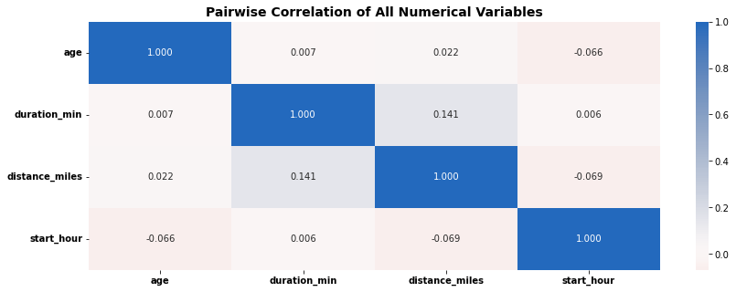

```python
# make a list of the numerical variables
numeric_vars = ['age', 'duration_min', 'distance_miles', 'start_hour']

# set figure size
plt.figure(figsize = [14, 5])
# make a plot of the correlation
sb.heatmap(df_clean[numeric_vars].corr(), annot = True, fmt = '.3f', cmap = 'vlag_r', center = 0)
# format labels
plt.xticks(weight = 'bold')
plt.yticks(weight = 'bold')
# set title and format it
plt.title('Pairwise Correlation of All Numerical Variables', size = 14, weight = 'bold');
```

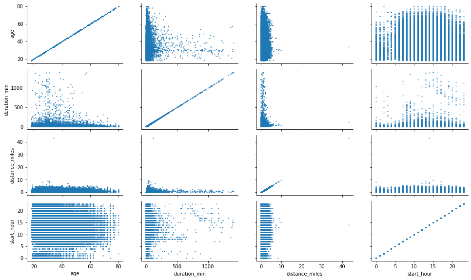

```python
# make a grid plot of all the numerical variables
g = sb.PairGrid(data = df_clean, vars = numeric_vars)
# set plot type and format it
g.map(plt.scatter, s = 1)
# set figure size
g.fig.set_size_inches(14, 8);
```

Observation 18: A very weak correlation exists amongst all unique pairs of numerical variables.

### Question 19: What does the combined relationship of age, trip duration and user type suggest?

```python
def map_plot(df, x_data, y_data, z_data, xs = 5, ys = 5, col_order = None):
    """
    This function makes a heatmap plot of the specified variables for a given DataFrame.

    Parameters:
        df: DataFrame of interest
        x_data (string): Numerical variable on the x_axis
        y_data (string): Numerical variable on the y_axis
        z_data (string): Categorical variable
        xs and ys = horizontal and vertical intervals respectively

    """
    # set bins
    xbin = np.arange((df[x_data].min() // xs) * xs, df[x_data].max() +xs, xs)
    ybin = np.arange(0, df[y_data].max() +ys, ys)

    # make the plot
    g = sb.FacetGrid(data = df, col = z_data, height = xs, col_order = col_order)
    g.map(plt.hist2d, x_data, y_data, cmin = 0.1, cmap = 'viridis_r', bins = [xbin, ybin])
    plt.colorbar()
    # set plot size
    g.fig.set_size_inches(14, 5);
```

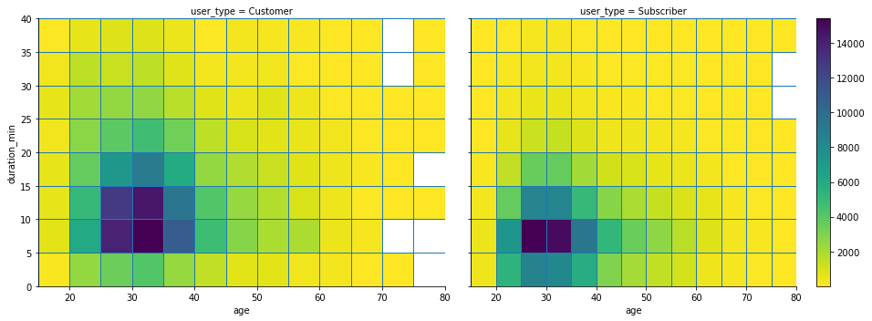

```python
# place emphasis on the region of interest
df = df_clean.query('duration_min < 40')
# make the plot
map_plot(df, 'age', 'duration_min', 'user_type');
```

Observation 19:

- On the average, customers spend more time on trips compared to subscribers.
- Compared to any other trip duration, customers aged 25 to 35 years are more likely to spend between 5 and 15 minutes on trips, while subscribers aged 25 to 35 years will most likely spend between 5 and 10 minutes on trips.

### Question 20: What does the combined relationship of age, trip duration and member gender reveal?

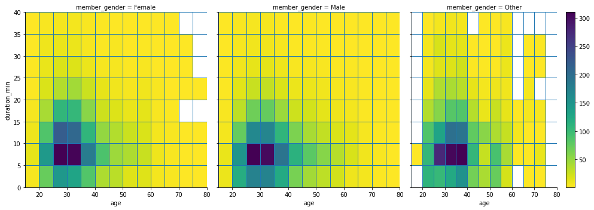

```python
# filter for the region of interest
df = df_clean.query('duration_min < 40')
# make the plot
map_plot(df, 'age', 'duration_min', 'member_gender');
```

Observation 20:

- Male users tend to spend spend less time on trips compared to any other gender, while other gender type tend to spend the most time on trips.
- The most likely amount of time any given gender will spend on a trip is between 5 and 10 minutes. For this specified amount of time, male and female users fall within the age limit of 25 and 35 years, while other gender type fall within the age group of 25 to 40 years.

### Question 21: What does the combined relationship of trip start hour, trip duration and user type reveal?

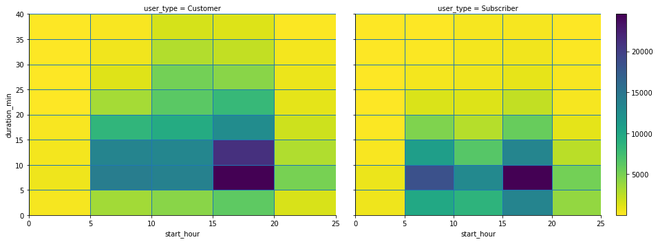

```python
# filter for the region of interest
df = df_clean.query('duration_min < 40')
# make the plot
map_plot(df, 'start_hour', 'duration_min', 'user_type');
```

Observation 21: Both customers and subscribers usually start their trips between 3:00 PM and 8:00 PM. While customers spend between 5 and 15 minutes, subscribers spend between 5 and 10 minutes.

### Question 22: What does the combined relationship of age, trip duration and bike sharing suggest?

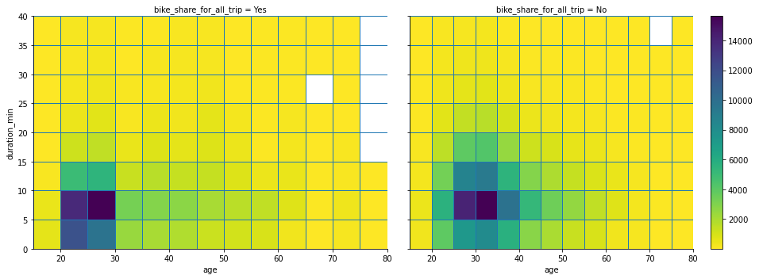

```python
# filter for the region of interest
df = df_clean.query('duration_min < 40')
# make the plot
map_plot(df, 'age', 'duration_min', 'bike_share_for_all_trip');
```

### Question 23: What does the combined relationship of age, trip duration and start day suggest?

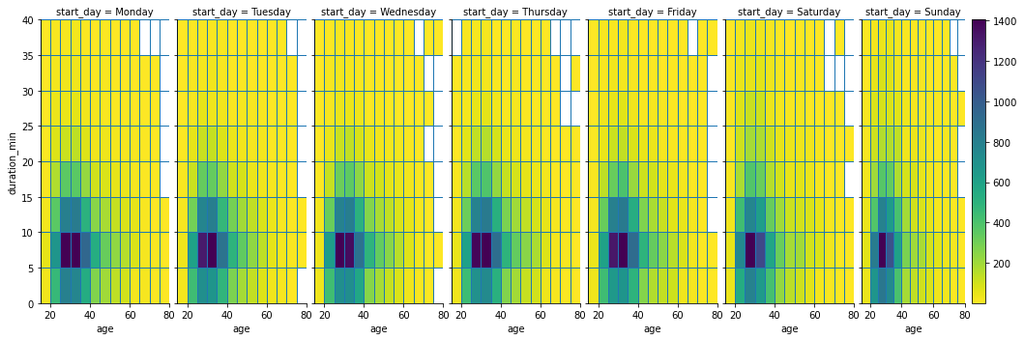

```python
# filter for the region of interest
df = df_clean.query('duration_min < 40')
# make the plot
map_plot(df, 'age', 'duration_min', 'start_day', col_order = day_order);
```

Observation 23: Over weekends, users aged 25 to 30 years will most likely spend between 5 and 10 minutes on trips. On weekdays, the age group that will most likely spend this specified amount of time on trips is 25 to 35 years.

### Were there any interesting or surprising interactions between features?

It was interesting to know that trip start hour had an effect on bike sharing.

## Conclusions

- On weekdays, the peak hours for trips are 8:00 AM and 5:00 PM. But on weekends, the peak start hour is by 12:00 noon.
- Bike sharing is only observed among subscribers. Customers do not share bikes.
- Most bike users fall within the ages of 25 and 35 years.
- A larger population of customers tend to travel farther distances compared to subscribers.
- A larger population of customers spend longer durations on trips compared to subscribers.
- Users who start their trips by 8:00 AM will most likely not share bikes.
- A very weak correlation exists amongst all unique pairs of numeric variables.
- On the average, customers spend more time on trips compared to subscribers.
- Male users tend to spend spend less time on trips compared to any other gender, while other gender type tend to spend the most time on trips.
- Over weekends, users aged 25 to 30 years will most likely spend between 5 and 10 minutes on trips. On weekdays, the age group that will most likely spend this specified amount of time on trips is 25 to 35 years.

```python
df_clean.to_csv('ford_gobike_master.csv', index=False)
```

## References

- https://stackoverflow.com/questions/19412462/getting-distance-between-two-points-based-on-latitude-longitude
- https://classroom.udacity.com/nanodegrees/nd002-alg-t2/parts/cd0016